# Forecast evaluation in mvgam

Nicholas J Clark

2026-06-26

A forecast is only as useful as the score that judges it. The choice of scoring rule shapes which model wins a comparison, which forecast horizons get the credit, and which corner of the posterior gets blamed for misses. This article walks through the mvgam forecast-evaluation surface on a real ecological dataset. We cover the three workflow stages every applied user runs into. `loo()` ranks the training fit. `forecast()` plus `score()` gives a fixed-window evaluation against a holdout. `lfo_cv()` runs rolling-origin evaluation that simulates a production forecasting workflow. We then build an ensemble that combines the strongest models and score it against its components.

All scoring rules used below are *proper* in the sense of Gneiting & Raftery ([2007](https://doi.org/10.1198/016214506000001437)): they are minimised in expectation by the true predictive distribution, so ranking models by score is well-defined.

## The data

`portal_data` ships with the package and carries four desert rodent species (DM, DO, PB, PP) trapped monthly at the Portal LTREB site, with two pre-standardised covariates: a 12-month moving average of NDVI (`ndvi_ma12`) and the previous month’s minimum temperature (`mintemp`). The response `captures` is an integer count; about 10% of the cells are missing because the field team could not always reach the plot.

```r
data(portal_data)
str(portal_data)
```

```
#> 'data.frame':    320 obs. of  5 variables:
#>  $ time     : int  1 1 1 1 2 2 2 2 3 3 ...
#>  $ series   : Factor w/ 4 levels "DM","DO","PB",..: 1 2 3 4 1 2 3 4 1 2 ...
#>  $ captures : int  20 2 0 0 NA NA NA NA 36 5 ...
#>  $ ndvi_ma12: num  -0.172 -0.172 -0.172 -0.172 -0.237 ...
#>  $ mintemp  : num  -0.796 -0.796 -0.796 -0.796 -1.335 ...
```

```r
head(portal_data, 4)
```

```
#>   time series captures  ndvi_ma12    mintemp
#> 1    1     DM       20 -0.1721441 -0.7963381
#> 2    1     DO        2 -0.1721441 -0.7963381
#> 3    1     PB        0 -0.1721441 -0.7963381
#> 4    1     PP        0 -0.1721441 -0.7963381
```

We split the 80 monthly timepoints into a 68-month training window and a 12-month holdout for forecast evaluation.

```r
train <- subset(portal_data, time <= 68L)
test  <- subset(portal_data, time >  68L)
c(train_rows = nrow(train), test_rows = nrow(test))
```

```
#> train_rows  test_rows
#>        272         48
```

The four series have markedly different abundance levels and temporal patterns. `mvgam_data()` gives the four-panel EDA view for one series and the faceted multi-series view when `series = "all"`:

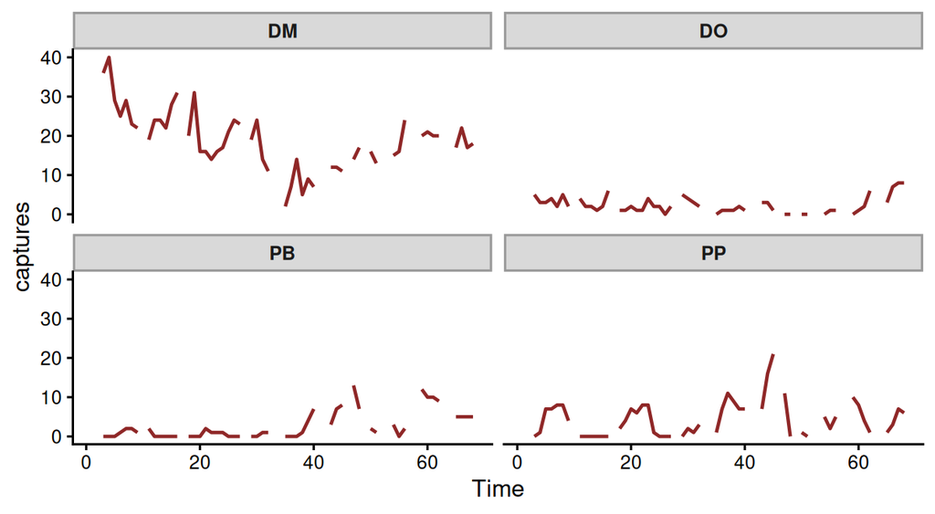

```r
mvgam_data(train, family = poisson(), y = "captures",
            series = "all")
```

## Three candidate models

We fit three models in increasing structural complexity. Each is a Bayesian Poisson regression on the captures, but they differ in how they handle the temporal signal beyond the smooths on NDVI and minimum temperature.

**Model 1, smooths only (`mod_spline`).** A baseline GAM with per-species temporal smooths. No state-space dynamics; the forecast extrapolates the spline trajectories, which often misses on count data because splines were not designed for forecasting.

```r
mod_spline <- mvgam(
  captures ~ s(mintemp, k = 6) + s(ndvi_ma12, k = 6) +
    s(time, by = series, k = 8) + series,
  family = poisson(),
  data   = train,
  chains = 2L, samples = 600L, silent = 2L
)
```

**Model 2, per-species AR(1) (`mod_ar`).** Replaces the temporal spline with an independent AR(1) state-space process for each species. Each species’ latent state evolves with its own auto-correlation; the obs-side smooths handle the covariate response.

```r
mod_ar <- mvgam(
  captures ~ s(mintemp, k = 6) + s(ndvi_ma12, k = 6) + series,
  trend_formula = ~ AR(),
  family = poisson(),
  data   = train,
  chains = 2L, samples = 600L, silent = 2L
)
```

**Model 3, correlated VAR(1) (`mod_var`).** A vector autoregression with `cor = TRUE`, allowing latent states for the four species to be cross-correlated. If one species’ deviation predicts another’s, this model can use that information to sharpen multi-species forecasts.

```r
mod_var <- mvgam(
  captures ~ s(mintemp, k = 6) + s(ndvi_ma12, k = 6) + series,
  trend_formula = ~ VAR(cor = TRUE),
  family = poisson(),
  data   = train,
  chains = 2L, samples = 600L, silent = 2L
)
```

The VAR fit’s `summary()` shows the joint state-space machinery that distinguishes it from the simpler models:

```r
summary(mod_var, include_betas = FALSE)
```

[output not shown]

[output cut: 93 more lines]

```
#> Omega_trend[4,3]       1.18      0.62     0.32     2.76 1.00   781.24  1136.38
#> Omega_trend[1,4]      -0.10      0.14    -0.39     0.18 1.00   783.32   657.03
#> Omega_trend[2,4]       0.04      0.30    -0.48     0.73 1.01   841.86   940.40
#> Omega_trend[3,4]       1.18      0.62     0.32     2.76 1.00   781.24  1136.38
#> Omega_trend[4,4]       2.15      0.93     0.89     4.45 1.00   638.31  1238.08
#>
#> Draws were sampled using sampling(NUTS). For each parameter, Bulk_ESS
#> and Tail_ESS are effective sample size measures, and Rhat is the potential
#> scale reduction factor on split chains (at convergence, Rhat = 1).
#>
#> Next steps:
#>   - `pp_check(fit)`: posterior predictive checks
#>   - `forecast(fit, newdata = ...)`: out-of-sample forecasts
#>   - `loo(fit)` / `loo_compare(...)`: model fit + comparison
#> Use `how_to_cite(fit)` for a citation-ready model description.
```

The `A_trend` matrix carries the lag-1 cross-effects between species, and `Sigma_trend` (with `cor = TRUE`) is unstructured rather than diagonal.

## In-sample comparison: PSIS-LOO

PSIS-LOO (Vehtari et al. [2017](https://doi.org/10.1007/s11222-016-9696-4)) approximates leave-one-observation-out predictive density on the training set using Pareto-smoothed importance sampling, avoiding a full refit per fold.

```r
loo_spline <- loo(mod_spline)
loo_ar     <- loo(mod_ar)
loo_var    <- loo(mod_var)
loo_compare(loo_spline, loo_ar, loo_var)
```

```
#>        elpd_diff se_diff
#> model1      0.0       0.0
#> model3  -1037.5     113.4
#> model2 -64798.4    7105.2
```

```r
mw <- loo_model_weights(
  list(spline = loo_spline, ar = loo_ar, var = loo_var),
  method = "stacking"
)
mw
```

```
#> Method: stacking
#> ------
#>        weight
#> spline 1.000
#> ar     0.000
#> var    0.000
```

All weight lands on the spline; the state-space models receive zero. Stacking weights are not posterior probabilities. They are the linear combination weights that minimise predictive log loss across LOO folds when the candidate forecasts are mixed (Yao et al. [2018](https://doi.org/10.1214/17-BA1091)). Here the optimiser sees the spline winning every fold by a wide margin, so it allocates a single mass point.

This is the textbook PSIS-LOO failure mode when the model carries a latent trend, not a vindication of the spline. The reason is structural and worth dwelling on, because users hit it constantly when reaching for `loo()` on time-series fits.

The method targets the expected log predictive density of each fold in which a single observation is removed. It approximates that quantity cheaply by importance-sampling the full posterior, with Pareto smoothing on the weights. The approximation is valid only when omitting one observation shifts the posterior modestly, so the two posteriors overlap enough for the weights to behave. That assumption breaks for a state-space model in two compounding ways:

1. *The latent trend leaks information across the omitted point.* When observation $t$ is dropped, the latent state at $t$ is still sandwiched between the observed states at $t-1$ and $t+1$. Markov dynamics interpolate, and the model effectively sees through the gap. The ELPD it returns is therefore close to an in-sample density, not the true density at unseen data.
2. *The importance weights collapse.* The omitted observation strongly identifies the latent state at $t$, so dropping it shifts the posterior in a direction the importance ratio from one point cannot smooth. Pareto-k diagnostics climb past 0.7 on virtually every fold (you can confirm via `loo(mod_ar)$diagnostics$pareto_k`), so the PSIS approximation itself is unreliable.

The spline GAM has no latent trend, so neither problem applies and its LOO ELPD is honest. The verdict here is correct for the question PSIS-LOO actually asks: how well the model fits the points it was trained on. That is not the question forecasters care about.

For time-series forecast comparison the right diagnostic is **leave the future out**. Every evaluation point is then unseen relative to its training window, so there is no leak through neighbours and no broken importance ratio. The `lfo_cv()` section below runs exactly that comparison, and the ranking inverts.

## Out-of-sample forecasts

`forecast()` produces an `mvgam_forecast` object carrying the posterior predictive distribution at each held-out timepoint.

```r
fc_spline <- forecast(mod_spline, newdata = test)
fc_ar     <- forecast(mod_ar,     newdata = test)
fc_var    <- forecast(mod_var,    newdata = test)
```

The default `plot()` method shows the median forecast with 50% and 90% credible bands, with held-out observations overlaid:

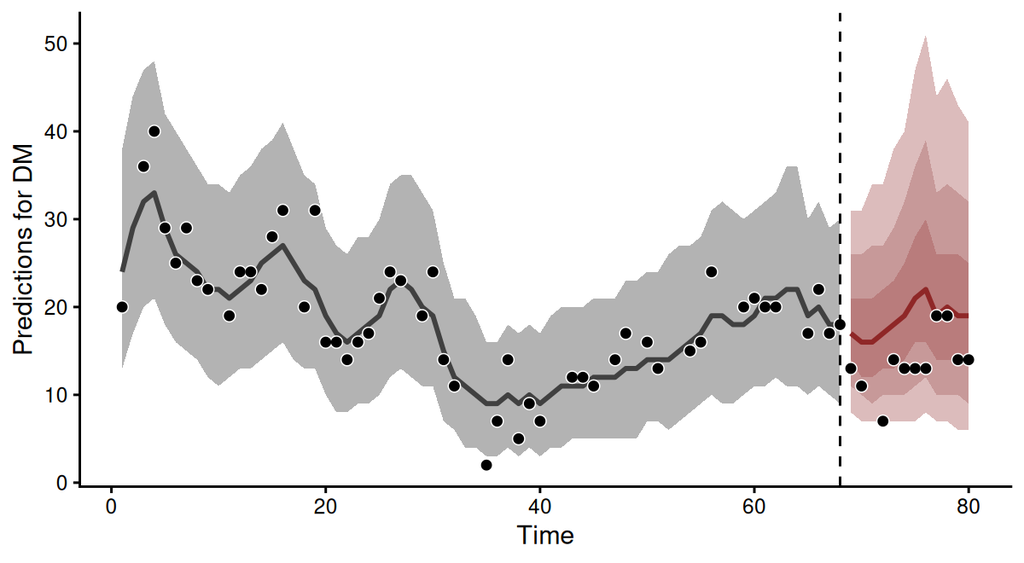

```r
plot(fc_var, series = 1)
```

The VAR forecast tracks the observed DM captures with bands that widen out by ~6 months. That is the canonical signature of a stationary AR process whose forecast variance asymptotes to the marginal variance.

For likelihood-based scoring (ELPD) we also need a link-scale forecast object:

```r
fc_spline_link <- forecast(mod_spline, newdata = test, type = "link")
fc_ar_link     <- forecast(mod_ar,     newdata = test, type = "link")
fc_var_link    <- forecast(mod_var,    newdata = test, type = "link")
```

## Univariate scoring

The CRPS (Continuous Ranked Probability Score) is the distributional analogue of mean absolute error. Lower is better. `score()` returns one row per evaluated timepoint per series:

```r
crps_var <- score(fc_var, score = "crps")
str(crps_var, max.level = 1)
```

```
#> List of 5
#>  $ DM        :'data.frame':  12 obs. of  5 variables:
#>  $ DO        :'data.frame':  12 obs. of  5 variables:
#>  $ PB        :'data.frame':  12 obs. of  5 variables:
#>  $ PP        :'data.frame':  12 obs. of  5 variables:
#>  $ all_series:'data.frame':  12 obs. of  3 variables:
```

```r
head(crps_var$DM, 4)
```

```
#>      score in_interval interval_width eval_horizon score_type
#> 1 2.589744           1            0.9            1       crps
#> 2 3.180448           1            0.9            2       crps
#> 3       NA          NA            0.9            3       crps
#> 4 6.987480           0            0.9            4       crps
```

The `in_interval` column carries a 0/1 indicator of whether the held-out observation fell inside the 90% predictive interval. Average it within a series for an empirical coverage estimate; if the model is well calibrated and the holdout is representative, that average sits near 0.9.

```r
sapply(crps_var[setdiff(names(crps_var), "all_series")],
       function(d) mean(d$in_interval, na.rm = TRUE))
```

```
#>        DM        DO        PB        PP
#> 0.9090909 0.7272727 1.0000000 1.0000000
```

`compare_scores()` bundles scores from several `mvgam_forecast` objects into one tidy frame. It returns one row per model x series x horizon, suitable for ggplot facets and summaries:

```r
crps_all <- compare_scores(fc_spline, fc_ar, fc_var, score = "crps")
head(crps_all)
```

```
#> # A tibble: 6 × 5
#>   model     series eval_horizon score in_interval
#>   <fct>     <fct>         <int> <dbl>       <dbl>
#> 1 fc_spline DM                1  2.12           1
#> 2 fc_spline DM                2  3.38           1
#> 3 fc_spline DM                3 NA             NA
#> 4 fc_spline DM                4  8.54           0
#> 5 fc_spline DM                5  3.57           1
#> 6 fc_spline DM                6  5.34           1
```

The frame has one row per model x series x horizon. Plot the per-series CRPS trajectories or compute differences between specific models directly from it. Here we plot CRPS by horizon for each species, coloured by model, with the per-series rows only (skipping the joint `all_series` row):

`plot()` dispatches on the `mvgam_compare_scores` class. For univariate scores it facets by series; switch to differences against any baseline model with `relative = "<model_name>"`.

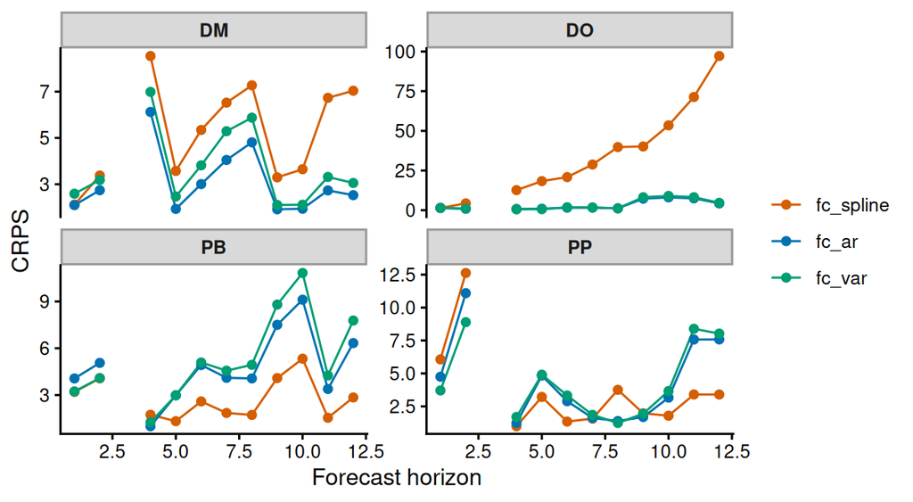

```r
plot(crps_all)
```

To see directly which horizons each state-space model beats the spline at, pivot to differences:

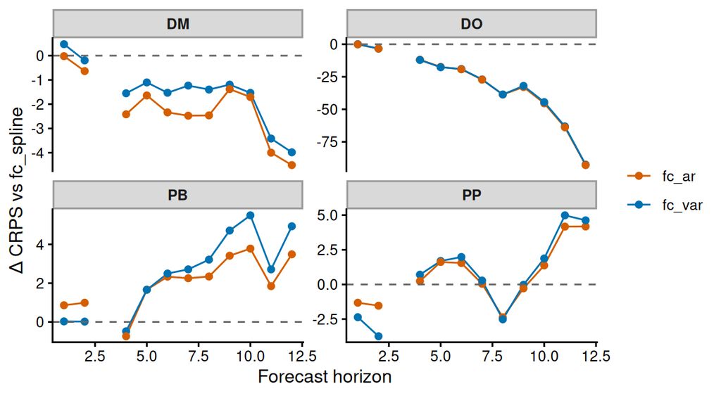

```r
plot(crps_all, relative = "fc_spline")
```

The log score (`score = "logs"`) evaluates the predictive log-density at each held out observation. The forecast object must use `type = "link"`:

```r
logs_var <- score(fc_var_link, score = "logs")
head(logs_var$DM, 4)
```

```
#>   score in_interval interval_width eval_horizon score_type
#> 1   Inf          NA            0.9            1       logs
#> 2   Inf          NA            0.9            2       logs
#> 3    NA          NA            0.9            3       logs
#> 4   Inf          NA            0.9            4       logs
```

For integer counts, the **discrete** ranked probability score is the count-aware sibling of CRPS:

```r
drps_var <- score(fc_var, score = "drps")
head(drps_var$DM, 4)
```

```
#>      score in_interval interval_width eval_horizon score_type
#> 1 2.589744           1            0.9            1       drps
#> 2 3.180448           1            0.9            2       drps
#> 3       NA          NA            0.9            3       drps
#> 4 6.987480           0            0.9            4       drps
```

DRPS and CRPS will rank models similarly, but DRPS is the principled choice when the response is bounded to integers because its units are the natural ones.

## Multivariate scoring

Univariate scoring sums per-series performance; it cannot reward a model for capturing the *joint* structure across species. Two proper scoring rules for joint forecasts are the **energy score** (Gneiting et al. [2008](https://doi.org/10.1007/s11749-008-0114-x)), a multivariate generalisation of CRPS, and the **variogram score** of order 0.5 (Scheuerer & Hamill [2015](https://doi.org/10.1175/MWR-D-14-00269.1)), which targets cross-series correlation structure.

```r
energy_var <- score(fc_var, score = "energy")
vario_var  <- score(fc_var, score = "variogram")
head(energy_var$all_series, 4)
```

```
#>       score eval_horizon score_type
#> 1  5.984723            1     energy
#> 2 10.062460            2     energy
#> 3        NA            3     energy
#> 4  7.504228            4     energy
```

```r
head(vario_var$all_series, 4)
```

```
#>      score eval_horizon score_type
#> 1 10.56502            1  variogram
#> 2 18.18365            2  variogram
#> 3       NA            3  variogram
#> 4 13.72148            4  variogram
```

Per-series rows still carry the coverage indicator but the joint score lives in `all_series`. Lower energy means better joint calibration; lower variogram means better recovery of pairwise dependencies.

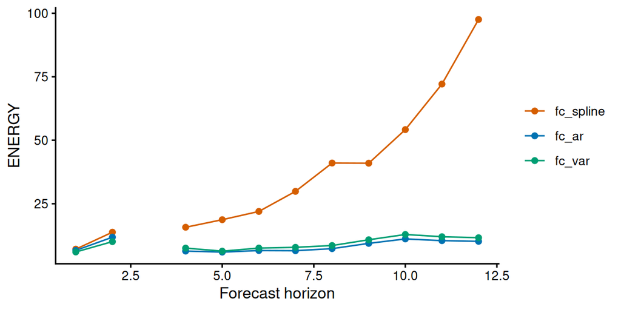

```r
energy_all <- compare_scores(fc_spline, fc_ar, fc_var,
                              score = "energy")
plot(energy_all)
```

## Rolling-origin evaluation with `lfo_cv()`

Approximate leave-future-out cross-validation (Bürkner, Gabry & Vehtari [2020](https://link.springer.com/article/10.1007/s00180-020-01045-4)) is the time-series-honest cousin of PSIS-LOO. Starting at a minimum training length `min_t`, the procedure expands the training window one timepoint at a time and forecasts `fc_horizon` steps ahead. At each step, PSIS importance weights are computed against the existing fit; only when Pareto-k exceeds a threshold (default 0.7) does mvgam refit the model. That hybrid scheme gives near-exact LFO ELPD at a fraction of the cost.

```r
lfo_spline <- lfo_cv(mod_spline, min_t = 60L, fc_horizon = 4L,
                      silent = 2L)
lfo_ar     <- lfo_cv(mod_ar,     min_t = 60L, fc_horizon = 4L,
                      silent = 2L)
lfo_var    <- lfo_cv(mod_var,    min_t = 60L, fc_horizon = 4L,
                      silent = 2L)
```

`lfo_cv()` returns an `mvgam_lfo` object whose `refits_at` slot records the timepoints at which Pareto-k forced an actual refit:

```r
list(
  spline = lfo_spline$refits_at,
  ar     = lfo_ar$refits_at,
  var    = lfo_var$refits_at
)
```

```
#> $spline
#> [1] 60 62 63 64
#>
#> $ar
#> [1] 60 61 62 63 64
#>
#> $var
#> [1] 60 61 62 63 64
```

`loo_compare()` works on `mvgam_lfo` objects directly:

```r
loo_compare(lfo_spline, lfo_ar, lfo_var)
```

```
#>            elpd_diff se_diff
#> lfo_ar           0.0     0.0
#> lfo_var        -15.2     2.3
#> lfo_spline     -29.9    10.2
```

Look at the trajectory of expected log predictive density across the rolling origin. A model whose ELPD trajectory rises faster (less negative) is forecasting better on average.

`compare_elpds()` is the LFO companion of `compare_scores()`. It stacks per-step ELPDs from several `mvgam_lfo` objects into a tidy frame keyed by `model` and `eval_time`.

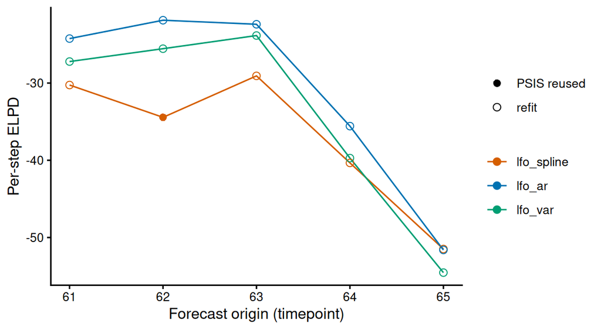

```r
lfo_df <- compare_elpds(lfo_spline, lfo_ar, lfo_var)
plot(lfo_df)
```

Toggle `cumulative = TRUE` to see how each model pulls ahead or falls behind across the rolling-origin window:

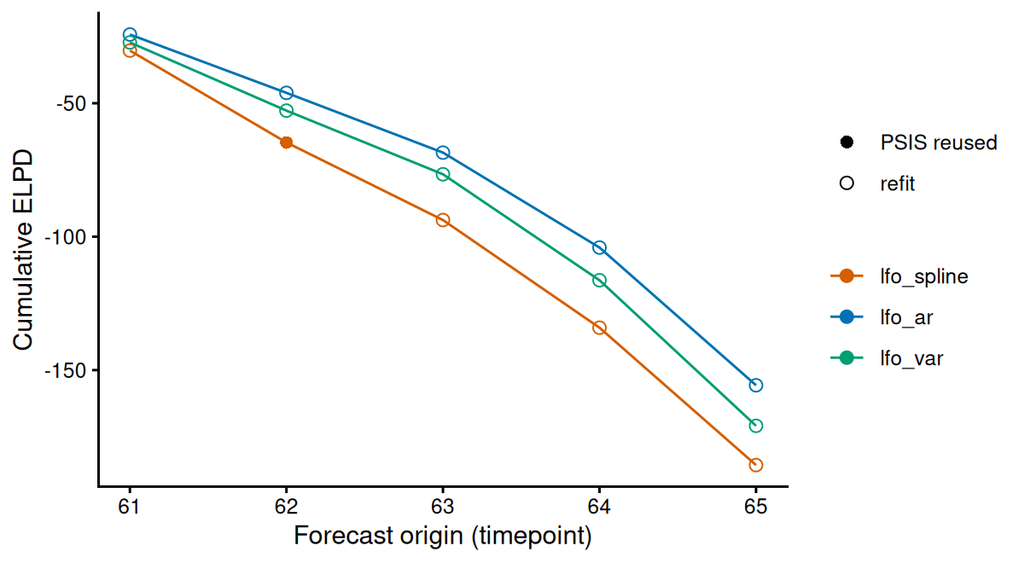

```r
plot(lfo_df, cumulative = TRUE)
```

The LFO ranking and the LOO ranking can disagree. When they do, trust LFO for forecasting decisions, because its evaluation set is the *future* relative to each training window, which is the only set that matches the production decision.

## Ensemble forecasting

`loo_model_weights()` on a set of `mvgam_lfo` objects offers two methods (Yao et al. 2018):

```r
lfo_weights <- loo_model_weights(lfo_spline, lfo_ar, lfo_var)
lfo_weights
```

```
#> Method: pseudo-BMA
#> ------
#>            weight
#> lfo_spline 0.000
#> lfo_ar     1.000
#> lfo_var    0.000
```

```r
stack_weights <- loo_model_weights(
  lfo_spline, lfo_ar, lfo_var,
  method = "stacking"
)
stack_weights
```

```
#> Method: stacking
#> ------
#>            weight
#> lfo_spline 0.003
#> lfo_ar     0.997
#> lfo_var    0.000
```

Stacking gives the same headline answer here. AR collects ~0.997 and the spline picks up a tiny ~0.003; VAR receives nothing. That convergence is not a coincidence: AR is the clear winner of the per-observation predictive density at most evaluation points, so the convex optimisation lands at almost the same corner of the simplex. When the headline model is this dominant, ensembling buys nothing.

Stacking is still the right default. In the more usual case where the candidates run closer to one another, the convex optimiser produces appreciably softer weights than pseudo-BMA (Yao et al. 2018, §3.3). Here it just happens to agree.

`ensemble()` builds a combined forecast object by resampling posterior draws from each component in proportion to the weights:

```r
fc_ens <- ensemble(
  fc_spline, fc_ar, fc_var,
  weights = as.numeric(stack_weights)
)
fc_ens
```

Score the ensemble alongside the individual models on the holdout window with `compare_scores()`. The honest comparison is on CRPS and energy:

`summary()` on a `mvgam_compare_scores` frame pivots it to one row per evaluation cell, with a column for each model. Read across the rows to see how the candidates differ on the same data point.

```r
crps_ens <- compare_scores(fc_spline, fc_ar, fc_var, fc_ens,
                             score = "crps",
                             model_names = c("spline", "ar",
                                              "var", "ensemble"))
summary(crps_ens)
```

```
#> # A tibble: 48 × 6
#>    series eval_horizon spline    ar   var ensemble
#>    <fct>         <int>  <dbl> <dbl> <dbl>    <dbl>
#>  1 DM                1   2.12  2.10  2.59     2.11
#>  2 DM                2   3.38  2.74  3.18     2.70
#>  3 DM                3  NA    NA    NA       NA
#>  4 DM                4   8.54  6.12  6.99     6.07
#>  5 DM                5   3.57  1.93  2.47     1.95
#>  6 DM                6   5.34  3.01  3.82     3.00
#>  7 DM                7   6.52  4.05  5.29     3.96
#>  8 DM                8   7.27  4.81  5.87     4.78
#>  9 DM                9   3.30  1.92  2.10     1.89
#> 10 DM               10   3.65  1.94  2.11     1.94
#> # ℹ 38 more rows
```

```r
energy_ens <- compare_scores(fc_spline, fc_ar, fc_var, fc_ens,
                               score = "energy",
                               model_names = c("spline", "ar",
                                                "var", "ensemble"))
summary(energy_ens)
```

```
#> # A tibble: 12 × 5
#>    eval_horizon spline    ar   var ensemble
#>           <int>  <dbl> <dbl> <dbl>    <dbl>
#>  1            1   7.10  6.61  5.98     6.63
#>  2            2  13.8  11.8  10.1     11.8
#>  3            3  NA    NA    NA       NA
#>  4            4  15.7   6.35  7.50     6.35
#>  5            5  18.7   5.93  6.30     5.95
#>  6            6  22.0   6.56  7.52     6.56
#>  7            7  29.9   6.49  7.82     6.49
#>  8            8  41.0   7.30  8.52     7.28
#>  9            9  40.9   9.38 10.8      9.40
#> 10           10  54.2  11.1  12.9     11.0
#> 11           11  72.1  10.4  12.0     10.4
#> 12           12  97.6  10.2  11.6     10.1
```

The ensemble does not beat the best individual on every species or every horizon. It is the *least bad* across the joint distribution of held-out evaluations, which is the right property when the user does not know in advance which species or horizon they will care about most.

## Take-aways

A forecast evaluation workflow in mvgam reuses the same fits three times. First, `loo()` and `loo_compare()` catch pathological models cheaply in sample. They do not pick a forecast model, though. For that, `forecast(newdata = test)` followed by `score()` is the workhorse. Use `score("crps")` or `score("drps")` for univariate calibration. Use `score("energy")` or `score("variogram")` when joint structure matters. The production question is often closer to “how would this model have performed run after run”: `lfo_cv()` plays out rolling forecasts and the hybrid PSIS scheme keeps the refitting cost low. Combine the candidates with `ensemble()` using stacking weights from `loo_model_weights()`, then score the ensemble on the same holdout the individuals saw. Pick the score that matches the decision. Pick the cross-validation that matches the production question.

## Further reading

The natural next functions to explore on the same fit are:

- `pp_check()` for posterior-predictive checks per outcome before any scoring runs.
- `conditional_effects()` and `marginaleffects::plot_predictions()` for the covariate surface that drives the forecast.
- `posterior_average()` and `pp_average()` for weighted posterior summaries across the candidate models the ensemble already mixes.
- `irf()`, `fevd()` and `stability()` for impulse response, forecast-error variance decomposition and stationarity diagnostics when the latent dynamics are a VAR.
- `methods_md()` for a citation-ready methods paragraph naming the architecture pieces the fit actually used.

Sibling articles in this series carry the workflow further:

- The [multi-response article](https://nicholasjclark.github.io/mvgam/articles/multivariate.html) shows how to share a single latent state across several outcomes with different observation families.
- The [JSDM article](https://nicholasjclark.github.io/mvgam/articles/jsdgam.html) applies the latent factor variant to multispecies count data with informed loadings via `jsdgam()`.
- For hierarchical or grouped trend dynamics (one shared trend per group with hyperpriors across groups), see `?gr` and the hierarchical-trends section of `vignette("mvgam_overview")`.

## Acknowledgements

The Portal Project rodent capture data ship with mvgam via `data(portal_data)` and are maintained by the Weecology group at https://github.com/weecology/PortalData. The forecast evaluation scheme comes from Bürkner, Gabry & Vehtari ([2020](https://doi.org/10.1080/00949655.2020.1783262)). The PSIS approximation is from Vehtari, Gelman & Gabry ([2017](https://doi.org/10.1007/s11222-016-9696-4)). Stacking weights are from Yao et al. ([2018](https://doi.org/10.1214/17-BA1091)). The univariate scoring framework is from Gneiting & Raftery ([2007](https://doi.org/10.1198/016214506000001437)). The energy score is from Gneiting et al. ([2008](https://doi.org/10.1007/s11749-008-0114-x)). The variogram score is from Scheuerer & Hamill ([2015](https://doi.org/10.1175/MWR-D-14-00269.1)). The multispecies forecasting framing follows Clark et al. ([2025](https://doi.org/10.7717/peerj.18929)).

## References

Bürkner P-C, Gabry J and Vehtari A (2020). Approximate leave-future-out cross-validation for Bayesian time series models. *Journal of Statistical Computation and Simulation* 90(14), 2499-2523. [doi:10.1080/00949655.2020.1783262](https://doi.org/10.1080/00949655.2020.1783262)

Clark NJ, Ernest SKM, Senyondo H, Simonis J, White EP, Yenni GM and Karunarathna KANK (2025). Beyond single-species models: multispecies forecasts to navigate the dynamics of ecological predictability. *PeerJ* 13, e18929. [doi:10.7717/peerj.18929](https://doi.org/10.7717/peerj.18929)

Gneiting T and Raftery AE (2007). Strictly proper scoring rules, prediction, and estimation. *Journal of the American Statistical Association* 102(477), 359-378. [doi:10.1198/016214506000001437](https://doi.org/10.1198/016214506000001437)

Gneiting T, Stanberry LI, Grimit EP, Held L and Johnson NA (2008). Assessing probabilistic forecasts of multivariate quantities, with an application to ensemble predictions of surface winds. *TEST* 17(2), 211-235. [doi:10.1007/s11749-008-0114-x](https://doi.org/10.1007/s11749-008-0114-x)

Scheuerer M and Hamill TM (2015). Variogram-based proper scoring rules for probabilistic forecasts of multivariate quantities. *Monthly Weather Review* 143(4), 1321-1334. [doi:10.1175/MWR-D-14-00269.1](https://doi.org/10.1175/MWR-D-14-00269.1)

Vehtari A, Gelman A and Gabry J (2017). Practical Bayesian model evaluation using leave-one-out cross-validation and WAIC. *Statistics and Computing* 27(5), 1413-1432. [doi:10.1007/s11222-016-9696-4](https://doi.org/10.1007/s11222-016-9696-4)

Yao Y, Vehtari A, Simpson D and Gelman A (2018). Using stacking to average Bayesian predictive distributions. *Bayesian Analysis* 13(3), 917-1003. [doi:10.1214/17-BA1091](https://doi.org/10.1214/17-BA1091)